# Analise de Mudanças Climáticas

### Analise de dados sobre Mudanças climáticas na Agricultura

### Nome: Maria Eduarda de Medeiros Leal

## Descrição do DataSet

O conjunto de dados utilizado neste projeto contém informações sobre os impactos das mudanças climáticas na produção agrícola, incluindo variáveis como temperatura, precipitação, rendimento das colheitas, e outros fatores ambientais e econômicos.

**Fonte do Dataset**: [Climate Change Impact on Agriculture](https://www.kaggle.com/datasets/waqi786/climate-change-impact-on-agriculture)  
**Autor do Dataset**: waqi786

## Descrição das variáveis

1. **Year**: Ano da coleta dos dados.
2. **Country**: País onde os dados foram coletados.
3. **Region**: Região específica dentro do país.
4. **Crop_Type**: Tipo de cultura plantada (ex: milho, trigo).
5. **Average_Temperature_C**: Temperatura média anual, em graus Celsius.
6. **Total_Precipitation_mm**: Precipitação total anual, em milímetros.
7. **CO2_Emissions_MT**: Emissões de dióxido de carbono (CO₂) em megatoneladas (MT).
8. **Crop_Yield_MT_per_HA**: Produtividade da cultura, medida em megatoneladas por hectare (MT/HA).
9. **Extreme_Weather_Events**: Número de eventos climáticos extremos registrados.
10. **Irrigation_Access_%**: Percentual de acesso à irrigação na região analisada.
11. **Pesticide_Use_KG_per_HA**: Uso de pesticidas, em quilogramas por hectare (KG/HA).
12. **Fertilizer_Use_KG_per_HA**: Uso de fertilizantes, em quilogramas por hectare (KG/HA).
13. **Soil_Health_Index**: Índice de saúde do solo (em uma escala de 0 a 100).
14. **Adaptation_Strategies**: Estratégias de adaptação empregadas pelos agricultores (ex: manejo da água, rotação de culturas).
15. **Economic_Impact_Million_USD**: Impacto econômico estimado, em milhões de dólares americanos (USD).

## Objetivo do Projeto

O objetivo deste projeto é explorar e analisar como as mudanças climáticas, especialmente a variação de temperatura e precipitação, estão afetando a produção agrícola em diferentes regiões ao longo do tempo. As principais variáveis de interesse incluem:

- **Average_Temperature_C**: Temperatura média anual, essencial para entender o impacto do calor nas colheitas.
- **Crop_Yield_MT_per_HA**: Produtividade das culturas, que mede o rendimento em relação às condições climáticas.

```python
# Importação das bibliotecas necessárias
import pandas as pd

# Caminho para o arquivo CSV (ajuste se necessário)
caminho_arquivo = '/kaggle/input/dataset/climate_change_impact_on_agriculture_2024.csv'

# Carregar o dataset em um DataFrame do pandas
dados_agricultura = pd.read_csv(caminho_arquivo)

# Corrigir os valores incorretos na coluna 'Crop_Yield_MT_per_HA'
dados_agricultura['Crop_Yield_MT_per_HA'] = dados_agricultura['Crop_Yield_MT_per_HA'].apply(lambda x: x if x < 100 else None)

# Preencher os valores faltantes (NaN) com a média da coluna
media_rendimento = dados_agricultura['Crop_Yield_MT_per_HA'].mean()
dados_agricultura['Crop_Yield_MT_per_HA'] = dados_agricultura['Crop_Yield_MT_per_HA'].fillna(media_rendimento)

# Perguntar ao usuário se ele deseja visualizar todos os dados
# mostrar_todos = input("Você gostaria de visualizar todos os dados? (s/n): ").strip().lower()

# if mostrar_todos == 's':
#     # Exibir todos os dados de forma bonita
#     from IPython.display import display
#     display(dados_agricultura)
# else:
#     # Perguntar quantas linhas o usuário gostaria de ver
#     try:
#         numero_linhas = int(input("Quantas linhas você gostaria de visualizar? "))
#         print(f"\nVisualizando {numero_linhas} linhas aleatórias dos dados:")
#         display(dados_agricultura.sample(numero_linhas))
#     except ValueError:
#         print("Entrada inválida. Exibindo 5 linhas por padrão.")
#         display(dados_agricultura.head())
display(dados_agricultura.head())
# Análise de valores vazios (NaN) em cada coluna
print("\n\nAnálise de valores faltantes em cada coluna:\n")
valores_vazios = dados_agricultura.isnull().sum()
display(valores_vazios)

# Verificar a porcentagem de valores faltantes por coluna
print("\n\nPorcentagem de valores faltantes por coluna:\n")
percentual_valores_vazios = (dados_agricultura.isnull().mean() * 100).round(2)
display(percentual_valores_vazios)
```

|  | Year | Country | Region | Crop_Type | Average_Temperature_C | Total_Precipitation_mm | CO2_Emissions_MT | Crop_Yield_MT_per_HA | Extreme_Weather_Events | Irrigation_Access_% | Pesticide_Use_KG_per_HA | Fertilizer_Use_KG_per_HA | Soil_Health_Index | Adaptation_Strategies | Economic_Impact_Million_USD |
| --- | --- | --- | --- | --- | --- | --- | --- | --- | --- | --- | --- | --- | --- | --- | --- |
| 0 | 2001 | India | West Bengal | Corn | 1.55 | 447.06 | 15.22 | 1.737 | 8 | 14.54 | 10.08 | 14.78 | 83.25 | Water Management | 808.13 |
| 1 | 2024 | China | North | Corn | 3.23 | 2913.57 | 29.82 | 1.737 | 8 | 11.05 | 33.06 | 23.25 | 54.02 | Crop Rotation | 616.22 |
| 2 | 2001 | France | Ile-de-France | Wheat | 21.11 | 1301.74 | 25.75 | 1.719 | 5 | 84.42 | 27.41 | 65.53 | 67.78 | Water Management | 796.96 |
| 3 | 2001 | Canada | Prairies | Coffee | 27.85 | 1154.36 | 13.91 | 3.890 | 5 | 94.06 | 14.38 | 87.58 | 91.39 | No Adaptation | 790.32 |
| 4 | 1998 | India | Tamil Nadu | Sugarcane | 2.19 | 1627.48 | 11.81 | 1.080 | 9 | 95.75 | 44.35 | 88.08 | 49.61 | Crop Rotation | 401.72 |

```
Análise de valores faltantes em cada coluna:
```

```
Year                           0
Country                        0
Region                         0
Crop_Type                      0
Average_Temperature_C          0
Total_Precipitation_mm         0
CO2_Emissions_MT               0
Crop_Yield_MT_per_HA           0
Extreme_Weather_Events         0
Irrigation_Access_%            0
Pesticide_Use_KG_per_HA        0
Fertilizer_Use_KG_per_HA       0
Soil_Health_Index              0
Adaptation_Strategies          0
Economic_Impact_Million_USD    0
dtype: int64
```

```
Porcentagem de valores faltantes por coluna:
```

```
Year                           0.0
Country                        0.0
Region                         0.0
Crop_Type                      0.0
Average_Temperature_C          0.0
Total_Precipitation_mm         0.0
CO2_Emissions_MT               0.0
Crop_Yield_MT_per_HA           0.0
Extreme_Weather_Events         0.0
Irrigation_Access_%            0.0
Pesticide_Use_KG_per_HA        0.0
Fertilizer_Use_KG_per_HA       0.0
Soil_Health_Index              0.0
Adaptation_Strategies          0.0
Economic_Impact_Million_USD    0.0
dtype: float64
```

## Analise de temperatura por região

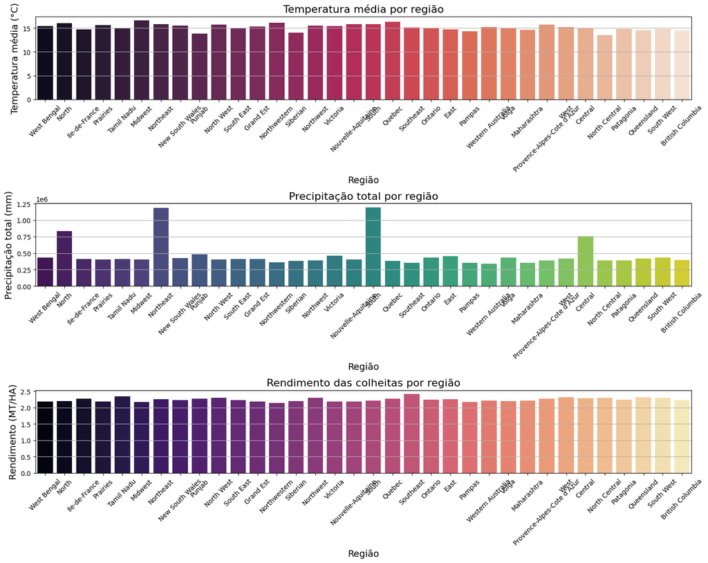

```python
import matplotlib.pyplot as plt
import seaborn as sns

# Configurando o gráfico
plt.figure(figsize=(15, 12))

# Gráfico de barras para temperatura média por região
plt.subplot(3, 1, 1)  # 3 linhas, 1 coluna, primeiro gráfico
sns.barplot(
    x='Region',  # Variável categórica no eixo x
    y='Average_Temperature_C',  # Variável numérica no eixo y
    data=dados_agricultura,  # DataFrame contendo os dados
    estimator='mean',  # Função de estimativa: calcula a média
    palette='rocket',  # Paleta de cores para o gráfico
    errorbar=None
)
plt.title('Temperatura média por região', fontsize=16)
plt.xlabel('Região', fontsize=14)
plt.ylabel('Temperatura média (°C)', fontsize=14)
plt.xticks(rotation=45)
plt.grid(axis='y')

# Gráfico de barras para precipitação total por região
plt.subplot(3, 1, 2)  # 3 linhas, 1 coluna, segundo gráfico
sns.barplot(
    x='Region',  # Variável categórica no eixo x
    y='Total_Precipitation_mm',  # Variável numérica no eixo y
    data=dados_agricultura,  # DataFrame contendo os dados
    estimator='sum',  # Função de estimativa: calcula a soma
    palette='viridis',  # Paleta de cores para o gráfico
    errorbar=None
)
plt.title('Precipitação total por região', fontsize=16)
plt.xlabel('Região', fontsize=14)
plt.ylabel('Precipitação total (mm)', fontsize=14)
plt.xticks(rotation=45)
plt.grid(axis='y')

# Gráfico de barras para rendimento por região em relação à temperatura
plt.subplot(3, 1, 3)  # 3 linhas, 1 coluna, terceiro gráfico
sns.barplot(
    x='Region',  # Variável categórica no eixo x
    y='Crop_Yield_MT_per_HA',  # Variável numérica no eixo y
    data=dados_agricultura,  # DataFrame contendo os dados
    estimator='mean',  # Função de estimativa: calcula a média
    palette='magma',  # Paleta de cores para o gráfico
    errorbar=None
)
plt.title('Rendimento das colheitas por região', fontsize=16)
plt.xlabel('Região', fontsize=14)
plt.ylabel('Rendimento (MT/HA)', fontsize=14)
plt.xticks(rotation=45)
plt.grid(axis='y')

# Ajustando o layout
plt.tight_layout()
plt.show()
```

# Aplicando Regressão Logística

```python
import pandas as pd
from sklearn.linear_model import LogisticRegression
from sklearn.model_selection import train_test_split
from sklearn.metrics import confusion_matrix, accuracy_score, classification_report

# Calcular média e desvio padrão do rendimento
media_rendimento = dados_agricultura['Crop_Yield_MT_per_HA'].mean()
desvio_padrao_rendimento = dados_agricultura['Crop_Yield_MT_per_HA'].std()


# Passo 3: Preparar os dados
X = dados_agricultura[['Average_Temperature_C']]  # Exemplo de variáveis
y = (dados_agricultura['Crop_Yield_MT_per_HA'] > 2).astype(int)

# Passo 4: Dividir os dados em conjuntos de treino e teste
X_train, X_test, y_train, y_test = train_test_split(X, y, test_size=0.5, random_state=30)

# Passo 5: Criar o modelo de regressão logística
modelo = LogisticRegression()

# Passo 6: Treinar o modelo
modelo.fit(X_train, y_train)

# Passo 7: Fazer previsões
y_pred = modelo.predict(X_test)

# Passo 8: Avaliar o modelo
# Matriz de confusão
matriz_confusao = confusion_matrix(y_test, y_pred)
print("Matriz de Confusão:")
print(matriz_confusao)

# Acurácia
acuracia = accuracy_score(y_test, y_pred)
print(f"Acurácia: {acuracia:.2f}")

# Relatório de Classificação
relatorio = classification_report(y_test, y_pred)
print("Relatório de Classificação:")
print(relatorio)
```

```
Matriz de Confusão:
[[1131 1080]
 [ 574 2215]]
Acurácia: 0.67
Relatório de Classificação:
              precision    recall  f1-score   support

           0       0.66      0.51      0.58      2211
           1       0.67      0.79      0.73      2789

    accuracy                           0.67      5000
   macro avg       0.67      0.65      0.65      5000
weighted avg       0.67      0.67      0.66      5000
```